# Visualization with IRIS dataset

**Importing pandas and Seaborn module**

```python
import pandas as pd
import seaborn as sns
import matplotlib.pyplot as plt
plt.style.use('fivethirtyeight')
import warnings
warnings.filterwarnings('ignore')  #this will ignore the warnings.it wont display warnings in notebook
```

**Importing Iris data set**

```python
iris=pd.read_csv('C:\\Users\\personal\\Desktop\\ML\\iris.csv')
```

**Displaying data**

```python
iris.head()
```

|  | sepal.length | sepal.width | petal.length | petal.width | variety |
| --- | --- | --- | --- | --- | --- |
| 0 | 5.1 | 3.5 | 1.4 | 0.2 | Setosa |
| 1 | 4.9 | 3.0 | 1.4 | 0.2 | Setosa |
| 2 | 4.7 | 3.2 | 1.3 | 0.2 | Setosa |
| 3 | 4.6 | 3.1 | 1.5 | 0.2 | Setosa |
| 4 | 5.0 | 3.6 | 1.4 | 0.2 | Setosa |

**Checking if there are any missing values**

```python
iris.info()
```

```
<class 'pandas.core.frame.DataFrame'>
RangeIndex: 150 entries, 0 to 149
Data columns (total 5 columns):
sepal.length    150 non-null float64
sepal.width     150 non-null float64
petal.length    150 non-null float64
petal.width     150 non-null float64
variety         150 non-null object
dtypes: float64(4), object(1)
memory usage: 5.3+ KB
```

```python
iris['variety'].value_counts()
```

```
Virginica     50
Setosa        50
Versicolor    50
Name: variety, dtype: int64
```

This data set has three varities of Iris plant.

**1. Describing the data**

```python
iris.describe()
```

|  | sepal.length | sepal.width | petal.length | petal.width |
| --- | --- | --- | --- | --- |
| count | 150.000000 | 150.000000 | 150.000000 | 150.000000 |
| mean | 5.843333 | 3.057333 | 3.758000 | 1.199333 |
| std | 0.828066 | 0.435866 | 1.765298 | 0.762238 |
| min | 4.300000 | 2.000000 | 1.000000 | 0.100000 |
| 25% | 5.100000 | 2.800000 | 1.600000 | 0.300000 |
| 50% | 5.800000 | 3.000000 | 4.350000 | 1.300000 |
| 75% | 6.400000 | 3.300000 | 5.100000 | 1.800000 |
| max | 7.900000 | 4.400000 | 6.900000 | 2.500000 |

**2.Bar Plot :** Here the frequency of the observation is plotted.In this case we are plotting the frequency of the three species in the Iris Dataset

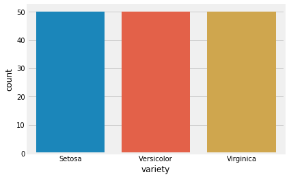

```python
sns.countplot('variety',data=iris)
plt.show()
```

**3. Pie Chart :**

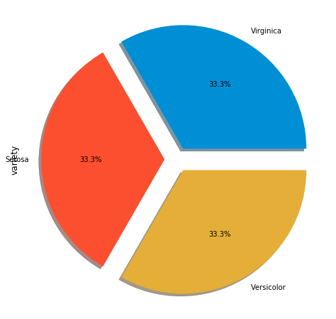

```python
iris['variety'].value_counts().plot.pie(explode=[0.1,0.1,0.1],autopct='%1.1f%%',shadow=True,figsize=(10,8))
plt.show()
```

We can see that there are 50 samples each of all the Iris Species in the data set.

**4. Joint plot:** Jointplot is seaborn library specific and can be used to quickly visualize and analyze the relationship between two variables and describe their individual distributions on the same plot.

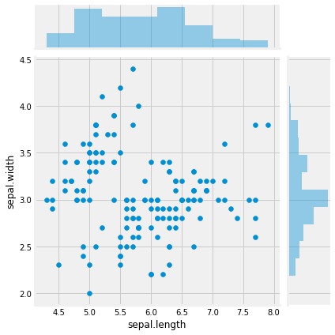

```python
fig=sns.jointplot(x='sepal.length',y='sepal.width',data=iris)
```

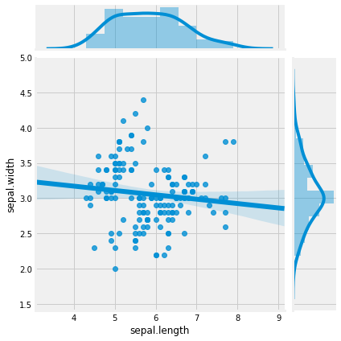

```python
sns.jointplot("sepal.length", "sepal.width", data=iris, kind="reg")
```

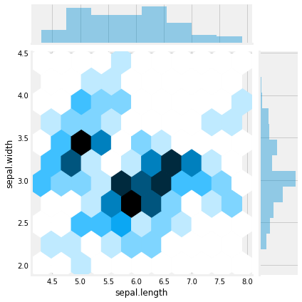

```python
fig=sns.jointplot(x='sepal.length',y='sepal.width',kind='hex',data=iris)
```

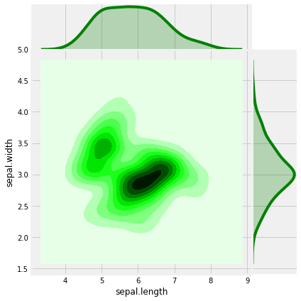

```python
sns.jointplot("sepal.length", "sepal.width", data=iris, kind="kde",space=0,color='g')
```

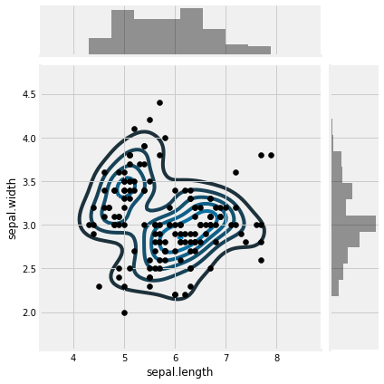

```python
g = (sns.jointplot("sepal.length", "sepal.width",data=iris, color="k").plot_joint(sns.kdeplot, zorder=0, n_levels=6))
```

**5. FacetGrid Plot**

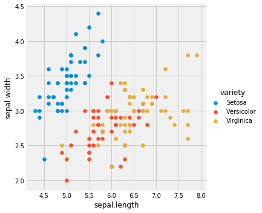

```python
import matplotlib.pyplot as plt
%matplotlib inline
sns.FacetGrid(iris,hue='variety',size=5)\
.map(plt.scatter,'sepal.length','sepal.width')\
.add_legend()
```

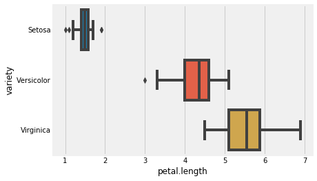

```python
sns.boxplot(x="petal.length", y="variety", data=iris)
```

[output not shown]

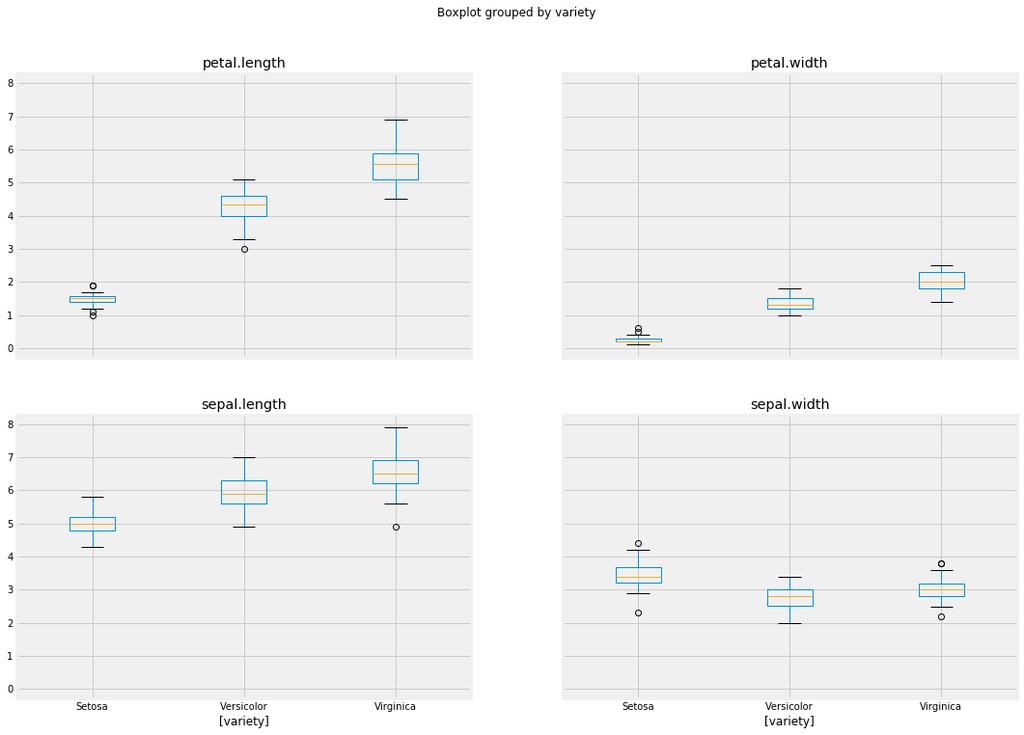

```python
iris.boxplot(by="variety", figsize=(18, 12))
```

**7. Strip plot**

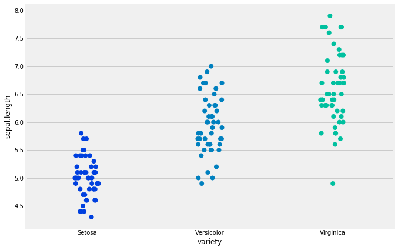

```python
fig=plt.gcf()
fig.set_size_inches(10,7)
fig=sns.stripplot(x='variety',y='sepal.length',data=iris,jitter=True,edgecolor='gray',size=8,palette='winter',orient='v')
```

**8. Combining Box and Strip Plots**

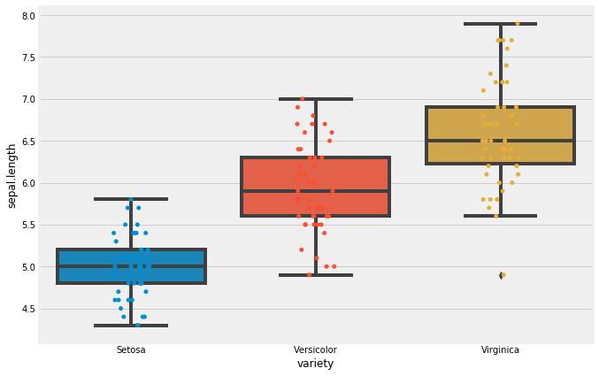

```python
fig=plt.gcf()
fig.set_size_inches(10,7)
fig=sns.boxplot(x='variety',y='sepal.length',data=iris)
fig=sns.stripplot(x='variety',y='sepal.length',data=iris,jitter=True)
```

**9. Violin Plot** It is used to visualize the distribution of data and its probability distribution.This chart is a combination of a Box Plot and a Density Plot that is rotated and placed on each side, to show the distribution shape of the data. The thick black bar in the centre represents the interquartile range, the thin black line extended from it represents the 95% confidence intervals, and the white dot is the median.Box Plots are limited in their display of the data, as their visual simplicity tends to hide significant details about how values in the data are distributed

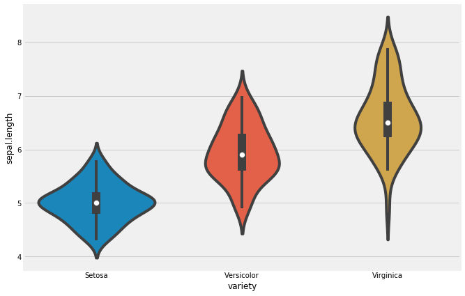

```python
fig=plt.gcf()
fig.set_size_inches(10,7)
fig=sns.violinplot(x='variety',y='sepal.length',data=iris)
```

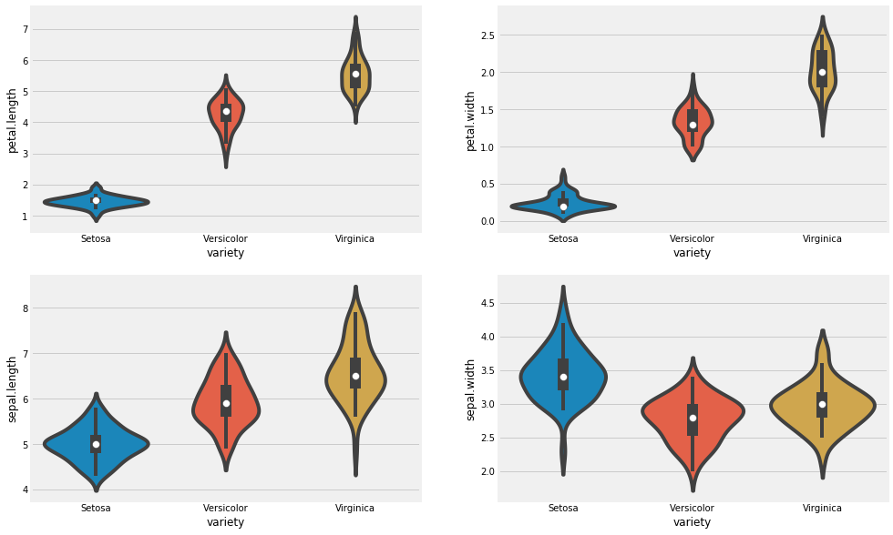

```python
plt.figure(figsize=(15,10))
plt.subplot(2,2,1)
sns.violinplot(x='variety',y='petal.length',data=iris)
plt.subplot(2,2,2)
sns.violinplot(x='variety',y='petal.width',data=iris)
plt.subplot(2,2,3)
sns.violinplot(x='variety',y='sepal.length',data=iris)
plt.subplot(2,2,4)
sns.violinplot(x='variety',y='sepal.width',data=iris)
```

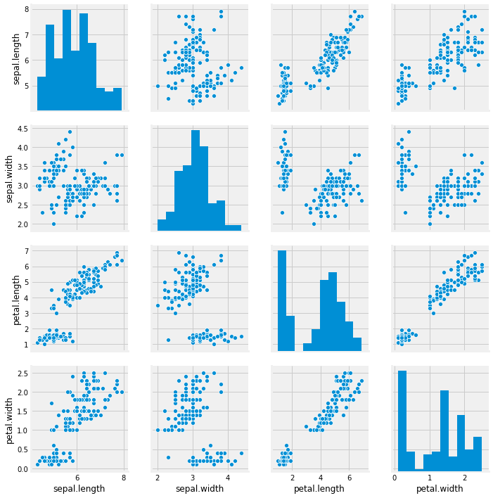

```python
sns.pairplot(data=iris,kind='scatter')
```

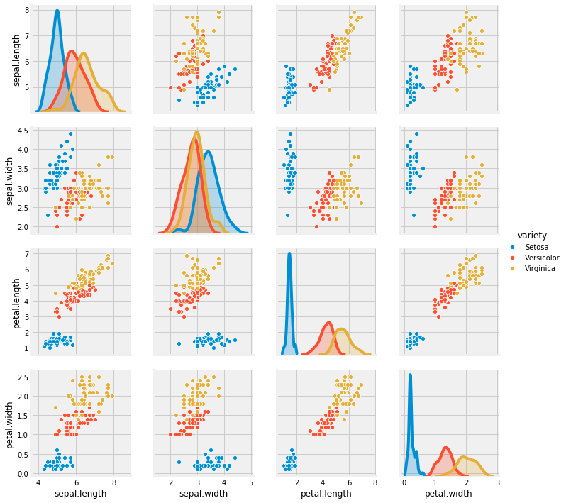

```python
sns.pairplot(iris,hue='variety')
```

**11. Heat map** Heat map is used to find out the correlation between different features in the dataset.High positive or negative value shows that the features have high correlation.This helps us to select the parmeters for machine learning.

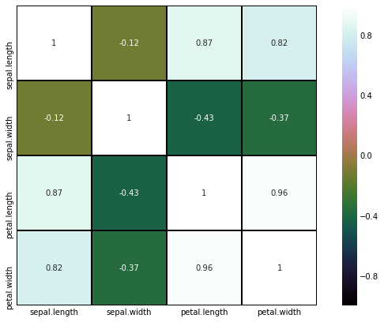

```python
fig=plt.gcf()
fig.set_size_inches(10,7)
fig=sns.heatmap(iris.corr(),annot=True,cmap='cubehelix',linewidths=1,linecolor='k',square=True,mask=False, vmin=-1, vmax=1,cbar_kws={"orientation": "vertical"},cbar=True)
```

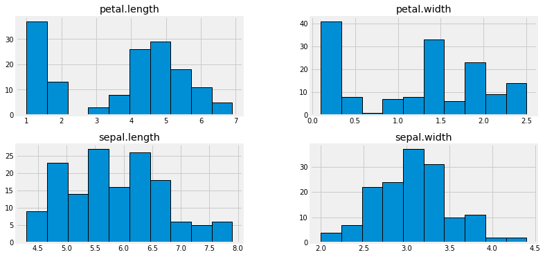

```python
iris.hist(edgecolor='black', linewidth=1)
fig=plt.gcf()
fig.set_size_inches(12,6)
```

**13. Swarm plot** It looks a bit like a friendly swarm of bees buzzing about their hive. More importantly, each data point is clearly visible and no data are obscured by overplotting.A beeswarm plot improves upon the random jittering approach to move data points the minimum distance away from one another to avoid overlays. The result is a plot where you can see each distinct data point, like shown in below plot

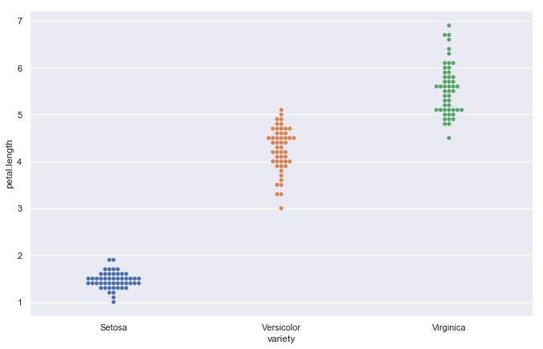

```python
sns.set(style="darkgrid")
fig=plt.gcf()
fig.set_size_inches(10,7)
fig = sns.swarmplot(x="variety", y="petal.length", data=iris)
```

**14. Box and Swarm plot combined**

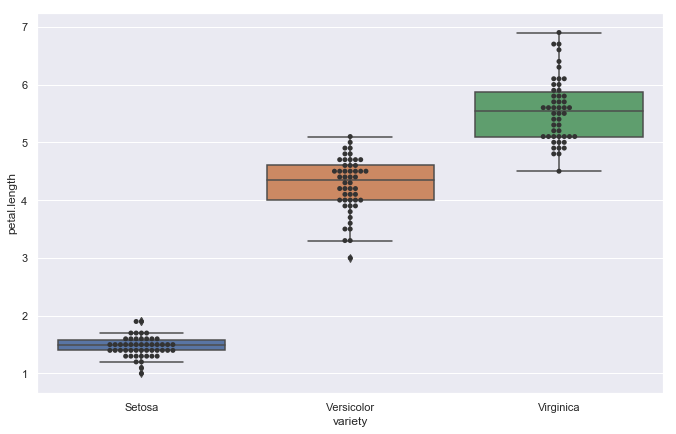

```python
sns.set(style="darkgrid")
fig=plt.gcf()
fig.set_size_inches(10,7)
fig= sns.boxplot(x="variety", y="petal.length", data=iris)
fig= sns.swarmplot(x="variety", y="petal.length", data=iris, color=".2")
```

**15. Swarm and Violin plot combined**

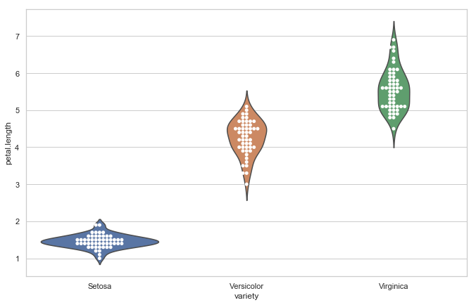

```python
sns.set(style="whitegrid")
fig=plt.gcf()
fig.set_size_inches(10,7)
ax = sns.violinplot(x="variety", y="petal.length", data=iris, inner=None)
ax = sns.swarmplot(x="variety", y="petal.length", data=iris,color="white", edgecolor="black")
```

**16. LM PLot**

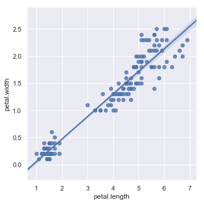

```python
fig=sns.lmplot(x="petal.length", y="petal.width",data=iris)
```

**17. FacetGrid**

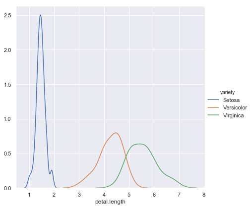

```python
sns.FacetGrid(iris, hue="variety", size=6) \
   .map(sns.kdeplot, "petal.length") \
   .add_legend()
plt.ioff()
```

**18. Andrews Curve:** In data visualization, an Andrews plot or Andrews curve is a way to visualize structure in high-dimensional data. It is basically a rolled-down, non-integer version of the Kent–Kiviat radar m chart, or a smoothened version of a parallel coordinate plot.In Pandas use Andrews Curves to plot and visualize data structure.Each multivariate observation is transformed into a curve and represents the coefficients of a Fourier series.This useful for detecting outliers in times series data.Use colormap to change the color of the curves

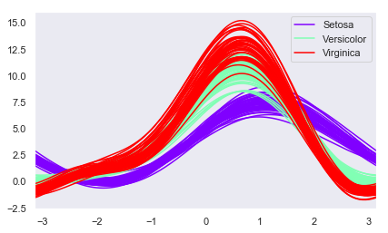

```python
from pandas.plotting import andrews_curves
andrews_curves(iris,"variety",colormap='rainbow')
plt.show()
plt.ioff()
```

**19. Parallel coordinate plot:** This type of visualisation is used for plotting multivariate, numerical data. Parallel Coordinates Plots are ideal for comparing many variables together and seeing the relationships between them. For example, if you had to compare an array of products with the same attributes (comparing computer or cars specs across different models).

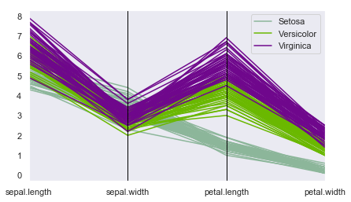

```python
from pandas.plotting import parallel_coordinates
parallel_coordinates(iris, "variety")
```

**20. Radviz Plot** RadViz Visualizer. RadViz is a multivariate data visualization algorithm that plots each feature dimension uniformly around the circumference of a circle then plots points on the interior of the circle such that the point normalizes its values on the axes from the center to each arc.

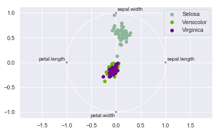

```python
from pandas.plotting import radviz
radviz(iris, "variety")
```

**21. Factor Plot**

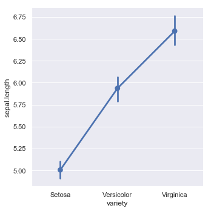

```python
sns.factorplot('variety','sepal.length',data=iris)
plt.ioff()
plt.show()
```

**22. Boxen Plot**|

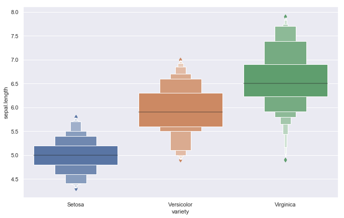

```python
fig=plt.gcf()
fig.set_size_inches(10,7)
fig=sns.boxenplot(x='variety',y='sepal.length',data=iris)
```

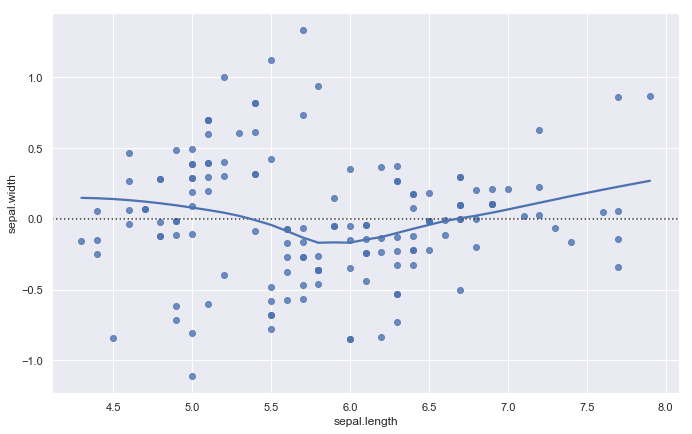

```python
fig=plt.gcf()
fig.set_size_inches(10,7)
fig=sns.residplot('sepal.length', 'sepal.width',data=iris,lowess=True)
```